# Face Generation

In this project, you'll define and train a Generative Adverserial network of your own creation on a dataset of faces. Your goal is to get a generator network to generate *new* images of faces that look as realistic as possible!

The project will be broken down into a series of tasks from **defining new architectures training adversarial networks**. At the end of the notebook, you'll be able to visualize the results of your trained Generator to see how it performs; your generated samples should look like fairly realistic faces with small amounts of noise.

### Get the Data

You'll be using the [CelebFaces Attributes Dataset (CelebA)](http://mmlab.ie.cuhk.edu.hk/projects/CelebA.html) to train your adversarial networks.

This dataset has higher resolution images than datasets you have previously worked with (like MNIST or SVHN) you've been working with, and so, you should prepare to define deeper networks and train them for a longer time to get good results. It is suggested that you utilize a GPU for training.

### Pre-processed Data

Since the project's main focus is on building the GANs, we've done *some* of the pre-processing for you. Each of the CelebA images has been cropped to remove parts of the image that don't include a face, then resized down to 64x64x3 NumPy images. Some sample data is show below.

[figure not shown]

> If you are working locally, you can download this data [by clicking here](https://s3.amazonaws.com/video.udacity-data.com/topher/2018/November/5be7eb6f_processed-celeba-small/processed-celeba-small.zip)

```python
# run this once to unzip the file
!unzip processed-celeba-small.zip
```

```
Archive:  processed-celeba-small.zip
replace processed_celeba_small/.DS_Store? [y]es, [n]o, [A]ll, [N]one, [r]ename:
```

```python
from glob import glob
from typing import Tuple, Callable, Dict
```

```python
import matplotlib.pyplot as plt
import numpy as np
import torch
```

```python
from PIL import Image
from torch.utils.data import DataLoader, Dataset
from torchvision.transforms import Compose, ToTensor

import tests
```

```python
data_dir = 'processed_celeba_small/celeba/'
```

## Data pipeline

### Pre-process and Load the Data

Since the project's main focus is on building the GANs, we've done *some* of the pre-processing for you. Each of the CelebA images has been cropped to remove parts of the image that don't include a face, then resized down to 64x64x3 NumPy images. This *pre-processed* dataset is a smaller subset of the very large CelebA dataset and contains roughly 30,000 images.

Your first task consists in building the dataloader. To do so, you need to do the following:

- implement the get_transforms function
- create a custom Dataset class that reads the CelebA data

### Exercise: implement the get_transforms function

The `get_transforms` function should output a [`torchvision.transforms.Compose`](https://pytorch.org/vision/stable/generated/torchvision.transforms.Compose.html#torchvision.transforms.Compose) of different transformations. You have two constraints:

- the function takes a tuple of size as input and should **resize the images** to the input size
- the output images should have values **ranging from -1 to 1**

```python
from torchvision.transforms import Resize, ToTensor, Normalize
def get_transforms(size: Tuple[int, int]) -> Callable:
    """ Transforms to apply to the image."""
    transforms = [
        Resize(size),          # Resizing the image to the input size
        ToTensor(),            # Convert the image to a PyTorch tensor
        Normalize((0.5, 0.5, 0.5), (0.5, 0.5, 0.5))  # Normalize to [-1, 1]
    ]
    return Compose(transforms)
```

### Exercise: implement the DatasetDirectory class

The `DatasetDirectory` class is a torch Dataset that reads from the above data directory. The `__getitem__` method should output a transformed tensor and the `__len__` method should output the number of files in our dataset. You can look at [this custom dataset](https://pytorch.org/tutorials/beginner/basics/data_tutorial.html#creating-a-custom-dataset-for-your-files) for ideas.

```python
from os import listdir
from os.path import join
class DatasetDirectory(Dataset):
    def __init__(self, directory: str, transforms: Callable = None, extension: str = '.jpg'):
        self.directory = directory
        self.transforms = transforms
        self.extension = extension
        self.image_files = [join(directory, file) for file in listdir(directory) if file.endswith(extension)]

    def __len__(self) -> int:
        return len(self.image_files)

    def __getitem__(self, index: int) -> torch.Tensor:
        img_path = self.image_files[index]
        image = Image.open(img_path).convert('RGB')  # Load image and convert to RGB
        if self.transforms:
            image = self.transforms(image)
        return image
```

```python
"""
DO NOT MODIFY ANYTHING IN THIS CELL
"""
# run this cell to verify your dataset implementation
dataset = DatasetDirectory(data_dir, get_transforms((64, 64)))
tests.check_dataset_outputs(dataset)
```

```
Congrats, your dataset implementation passed all the tests
```

The functions below will help you visualize images from the dataset.

[figure not shown]

```python
"""
DO NOT MODIFY ANYTHING IN THIS CELL
"""

def denormalize(images):
    """Transform images from [-1.0, 1.0] to [0, 255] and cast them to uint8."""
    return ((images + 1.) / 2. * 255).astype(np.uint8)

# plot the images in the batch, along with the corresponding labels
fig = plt.figure(figsize=(20, 4))
plot_size=20
for idx in np.arange(plot_size):
    ax = fig.add_subplot(2, int(plot_size/2), idx+1, xticks=[], yticks=[])
    img = dataset[idx].numpy()
    img = np.transpose(img, (1, 2, 0))
    img = denormalize(img)
    ax.imshow(img)
```

## Model implementation

As you know, a GAN is comprised of two adversarial networks, a discriminator and a generator. Now that we have a working data pipeline, we need to implement the discriminator and the generator.

Feel free to implement any additional class or function.

### Exercise: Create the discriminator

The discriminator's job is to score real and fake images. You have two constraints here:

- the discriminator takes as input a **batch of 64x64x3 images**
- the output should be a single value (=score)

Feel free to get inspiration from the different architectures we talked about in the course, such as DCGAN, WGAN-GP or DRAGAN.

#### Some tips

- To scale down from the input image, you can either use `Conv2d` layers with the correct hyperparameters or Pooling layers.
- If you plan on using gradient penalty, do not use Batch Normalization layers in the discriminator.

```python
import torch.nn as nn
```

```python
class Discriminator(nn.Module):
    def __init__(self):
        super(Discriminator, self).__init__()
        self.model = nn.Sequential(
            # Input is 3 x 64 x 64
            nn.Conv2d(3, 64, kernel_size=4, stride=2, padding=1),  # 64 x 32 x 32
            nn.LeakyReLU(0.2, inplace=True),

            nn.Conv2d(64, 128, kernel_size=4, stride=2, padding=1),  # 128 x 16 x 16
            nn.BatchNorm2d(128),
            nn.LeakyReLU(0.2, inplace=True),

            nn.Conv2d(128, 256, kernel_size=4, stride=2, padding=1),  # 256 x 8 x 8
            nn.BatchNorm2d(256),
            nn.LeakyReLU(0.2, inplace=True),

            nn.Conv2d(256, 512, kernel_size=4, stride=2, padding=1),  # 512 x 4 x 4
            nn.BatchNorm2d(512),
            nn.LeakyReLU(0.2, inplace=True),

            nn.Conv2d(512, 1, kernel_size=4, stride=1, padding=0),  # 1 x 1 x 1
            nn.Sigmoid()  # To output a single score between 0 and 1
        )

    def forward(self, x):
        return self.model(x)
```

```python
"""
DO NOT MODIFY ANYTHING IN THIS CELL
"""
# run this cell to check your discriminator implementation
discriminator = Discriminator()
tests.check_discriminator(discriminator)
```

```
Congrats, your discriminator implementation passed all the tests
```

### Exercise: create the generator

- the generator takes as input a vector of dimension `[batch_size, latent_dimension, 1, 1]`
- the generator must outputs **64x64x3 images**

Feel free to get inspiration from the different architectures we talked about in the course, such as DCGAN, WGAN-GP or DRAGAN.

#### Some tips:

- to scale up from the latent vector input, you can use `ConvTranspose2d` layers
- as often with Gan, **Batch Normalization** helps with training

```python
class Generator(nn.Module):
    def __init__(self, latent_dim: int):
        super(Generator, self).__init__()
        self.model = nn.Sequential(
            nn.ConvTranspose2d(latent_dim, 512, kernel_size=4, stride=1, padding=0),
            nn.BatchNorm2d(512),
            nn.ReLU(True),
            nn.ConvTranspose2d(512, 256, kernel_size=4, stride=2, padding=1),
            nn.BatchNorm2d(256),
            nn.ReLU(True),
            nn.ConvTranspose2d(256, 128, kernel_size=4, stride=2, padding=1),
            nn.BatchNorm2d(128),
            nn.ReLU(True),
            nn.ConvTranspose2d(128, 64, kernel_size=4, stride=2, padding=1),
            nn.BatchNorm2d(64),
            nn.ReLU(True),
            nn.ConvTranspose2d(64, 3, kernel_size=4, stride=2, padding=1),
            nn.Tanh()  # Output images scaled between [-1, 1]
        )

    def forward(self, x):
        return self.model(x)
```

```python
"""
DO NOT MODIFY ANYTHING IN THIS CELL
"""
# run this cell to verify your generator implementation
latent_dim = 128
generator = Generator(latent_dim)
tests.check_generator(generator, latent_dim)
```

```
Congrats, your generator implementation passed all the tests
```

## Optimizer

In the following section, we create the optimizers for the generator and discriminator. You may want to experiment with different optimizers, learning rates and other hyperparameters as they tend to impact the output quality.

### Exercise: implement the optimizers

```python
import torch.optim as optim
from torch.nn import Module
def create_optimizers(generator: Module, discriminator: Module):
    g_optimizer = optim.Adam(generator.parameters(), lr=0.0002, betas=(0.5, 0.999))
    d_optimizer = optim.Adam(discriminator.parameters(), lr=0.0002, betas=(0.5, 0.999))
    return g_optimizer, d_optimizer
```

## Losses implementation

In this section, we are going to implement the loss function for the generator and the discriminator. You can and should experiment with different loss function.

Some tips:

- You can choose the commonly used the binary cross entropy loss or select other losses we have discovered in the course, such as the Wasserstein distance.
- You may want to implement a gradient penalty function as discussed in the course. It is not required and the code will work whether you implement it or not.

### Exercise: implement the generator loss

The generator's goal is to get the discriminator to think its generated images (= "fake" images) are real.

```python
def generator_loss(fake_logits):
    return nn.BCELoss()(fake_logits, torch.ones_like(fake_logits))
```

### Exercise: implement the discriminator loss

We want the discriminator to give high scores to real images and low scores to fake ones and the discriminator loss should reflect that.

```python
def discriminator_loss(real_logits, fake_logits):
    real_loss = nn.BCELoss()(real_logits, torch.ones_like(real_logits))
    fake_loss = nn.BCELoss()(fake_logits, torch.zeros_like(fake_logits))
    return real_loss + fake_loss
```

### Exercise (Optional): Implement the gradient Penalty

In the course, we discussed the importance of gradient penalty in training certain types of Gans. Implementing this function is not required and depends on some of the design decision you made (discriminator architecture, loss functions).

```python
def gradient_penalty(discriminator, real_samples, fake_samples):
    """ This function enforces """
    gp = 0
    # TODO (Optional): implement the gradient penalty
    return gp
```

## Training

- You should train the discriminator by alternating on real and fake images
- Then the generator, which tries to trick the discriminator and should have an opposing loss function

### Exercise: implement the generator step and the discriminator step functions

Each function should do the following:

- calculate the loss
- backpropagate the gradient
- perform one optimizer step

```python
def generator_step(batch_size: int, latent_dim: int) -> Dict:
    generator.zero_grad()
    latent_vectors = torch.randn(batch_size, latent_dim, 1, 1).to(device)
    fake_images = generator(latent_vectors)
    fake_logits = discriminator(fake_images)
    g_loss = generator_loss(fake_logits)
    g_loss.backward()
    g_optimizer.step()
    return {'loss': g_loss.item()}

def discriminator_step(batch_size: int, latent_dim: int, real_images: torch.Tensor) -> Dict:
    discriminator.zero_grad()
    # Real images
    real_logits = discriminator(real_images)
    # Fake images
    latent_vectors = torch.randn(batch_size, latent_dim, 1, 1).to(device)
    fake_images = generator(latent_vectors)
    fake_logits = discriminator(fake_images.detach())
    # Loss calculation
    d_loss = discriminator_loss(real_logits, fake_logits)
    d_loss.backward()
    d_optimizer.step()
    return {'loss': d_loss.item()}
```

### Main training loop

You don't have to implement anything here but you can experiment with different hyperparameters.

```python
from datetime import datetime
```

```python
# you can experiment with different dimensions of latent spaces
latent_dim = 128

# update to cpu if you do not have access to a gpu
device = 'cuda'

# number of epochs to train your model
n_epochs = 5

# number of images in each batch
batch_size = 64
```

```python
"""
DO NOT MODIFY ANYTHING IN THIS CELL
"""
print_every = 50

# Create optimizers for the discriminator D and generator G
generator = Generator(latent_dim).to(device)
discriminator = Discriminator().to(device)
g_optimizer, d_optimizer = create_optimizers(generator, discriminator)

dataloader = DataLoader(dataset,
                        batch_size=64,
                        shuffle=True,
                        num_workers=4,
                        drop_last=True,
                        pin_memory=False)
```

```python
"""
DO NOT MODIFY ANYTHING IN THIS CELL
"""

def display(fixed_latent_vector: torch.Tensor):
    """ helper function to display images during training """
    fig = plt.figure(figsize=(14, 4))
    plot_size = 16
    for idx in np.arange(plot_size):
        ax = fig.add_subplot(2, int(plot_size/2), idx+1, xticks=[], yticks=[])
        img = fixed_latent_vector[idx, ...].detach().cpu().numpy()
        img = np.transpose(img, (1, 2, 0))
        img = denormalize(img)
        ax.imshow(img)
    plt.show()
```

### Exercise: implement the training strategy

You should experiment with different training strategies. For example:

- train the generator more often than the discriminator.
- added noise to the input image
- use label smoothing

Implement with your training strategy below.

```
2024-09-11 07:19:44 | Epoch [1/5] | Batch 0/509 | d_loss: 1.2661 | g_loss: 2.7795
2024-09-11 07:19:49 | Epoch [1/5] | Batch 50/509 | d_loss: 0.0030 | g_loss: 9.2197
2024-09-11 07:19:55 | Epoch [1/5] | Batch 100/509 | d_loss: 0.1838 | g_loss: 4.3402
2024-09-11 07:20:00 | Epoch [1/5] | Batch 150/509 | d_loss: 0.3547 | g_loss: 4.5993
2024-09-11 07:20:06 | Epoch [1/5] | Batch 200/509 | d_loss: 0.1232 | g_loss: 4.5161
2024-09-11 07:20:12 | Epoch [1/5] | Batch 250/509 | d_loss: 0.1293 | g_loss: 3.9035
2024-09-11 07:20:17 | Epoch [1/5] | Batch 300/509 | d_loss: 0.5317 | g_loss: 1.6286
2024-09-11 07:20:23 | Epoch [1/5] | Batch 350/509 | d_loss: 0.7597 | g_loss: 4.1006
2024-09-11 07:20:29 | Epoch [1/5] | Batch 400/509 | d_loss: 1.1027 | g_loss: 4.9493
2024-09-11 07:20:35 | Epoch [1/5] | Batch 450/509 | d_loss: 0.3086 | g_loss: 2.8878
2024-09-11 07:20:40 | Epoch [1/5] | Batch 500/509 | d_loss: 0.2719 | g_loss: 2.9681
```

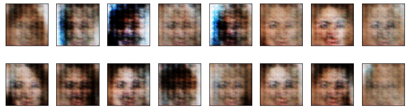

```
2024-09-11 07:20:46 | Epoch [2/5] | Batch 0/509 | d_loss: 0.2697 | g_loss: 3.8742
2024-09-11 07:20:52 | Epoch [2/5] | Batch 50/509 | d_loss: 0.3135 | g_loss: 6.2946
2024-09-11 07:20:58 | Epoch [2/5] | Batch 100/509 | d_loss: 0.3588 | g_loss: 3.8258
2024-09-11 07:21:04 | Epoch [2/5] | Batch 150/509 | d_loss: 0.4506 | g_loss: 6.2259
2024-09-11 07:21:10 | Epoch [2/5] | Batch 200/509 | d_loss: 0.3145 | g_loss: 4.7466
2024-09-11 07:21:16 | Epoch [2/5] | Batch 250/509 | d_loss: 0.4233 | g_loss: 3.5618
2024-09-11 07:21:22 | Epoch [2/5] | Batch 300/509 | d_loss: 0.7765 | g_loss: 3.8836
2024-09-11 07:21:28 | Epoch [2/5] | Batch 350/509 | d_loss: 0.4734 | g_loss: 4.6703
2024-09-11 07:21:34 | Epoch [2/5] | Batch 400/509 | d_loss: 0.7564 | g_loss: 4.2325
2024-09-11 07:21:40 | Epoch [2/5] | Batch 450/509 | d_loss: 0.1931 | g_loss: 4.7214
2024-09-11 07:21:46 | Epoch [2/5] | Batch 500/509 | d_loss: 0.2645 | g_loss: 4.2340
```

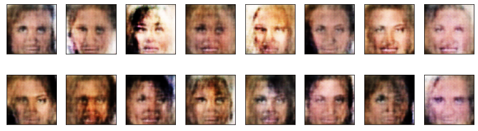

```
2024-09-11 07:21:51 | Epoch [3/5] | Batch 0/509 | d_loss: 0.7269 | g_loss: 5.2254
2024-09-11 07:21:57 | Epoch [3/5] | Batch 50/509 | d_loss: 1.0985 | g_loss: 8.5436
2024-09-11 07:22:03 | Epoch [3/5] | Batch 100/509 | d_loss: 1.7915 | g_loss: 6.9335
2024-09-11 07:22:09 | Epoch [3/5] | Batch 150/509 | d_loss: 0.4360 | g_loss: 5.2818
2024-09-11 07:22:15 | Epoch [3/5] | Batch 200/509 | d_loss: 0.5288 | g_loss: 3.2481
2024-09-11 07:22:21 | Epoch [3/5] | Batch 250/509 | d_loss: 0.8694 | g_loss: 6.7276
2024-09-11 07:22:28 | Epoch [3/5] | Batch 300/509 | d_loss: 0.3729 | g_loss: 4.7298
2024-09-11 07:22:34 | Epoch [3/5] | Batch 350/509 | d_loss: 0.4232 | g_loss: 3.9490
2024-09-11 07:22:40 | Epoch [3/5] | Batch 400/509 | d_loss: 0.8091 | g_loss: 2.1218
2024-09-11 07:22:46 | Epoch [3/5] | Batch 450/509 | d_loss: 0.5392 | g_loss: 4.9806
2024-09-11 07:22:52 | Epoch [3/5] | Batch 500/509 | d_loss: 1.1976 | g_loss: 8.3049
```

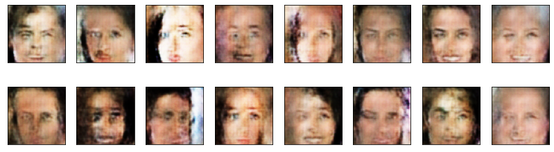

```
2024-09-11 07:22:57 | Epoch [4/5] | Batch 0/509 | d_loss: 0.6085 | g_loss: 6.3599
2024-09-11 07:23:03 | Epoch [4/5] | Batch 50/509 | d_loss: 0.5130 | g_loss: 5.0113
2024-09-11 07:23:10 | Epoch [4/5] | Batch 100/509 | d_loss: 0.1297 | g_loss: 5.3511
2024-09-11 07:23:16 | Epoch [4/5] | Batch 150/509 | d_loss: 0.8835 | g_loss: 1.8861
2024-09-11 07:23:22 | Epoch [4/5] | Batch 200/509 | d_loss: 0.9514 | g_loss: 0.4704
2024-09-11 07:23:28 | Epoch [4/5] | Batch 250/509 | d_loss: 0.3583 | g_loss: 2.2068
2024-09-11 07:23:34 | Epoch [4/5] | Batch 300/509 | d_loss: 1.0163 | g_loss: 7.0606
2024-09-11 07:23:40 | Epoch [4/5] | Batch 350/509 | d_loss: 0.3493 | g_loss: 3.8078
2024-09-11 07:23:46 | Epoch [4/5] | Batch 400/509 | d_loss: 0.3029 | g_loss: 3.5026
2024-09-11 07:23:52 | Epoch [4/5] | Batch 450/509 | d_loss: 0.2557 | g_loss: 3.7218
2024-09-11 07:23:58 | Epoch [4/5] | Batch 500/509 | d_loss: 0.6608 | g_loss: 5.7372
```

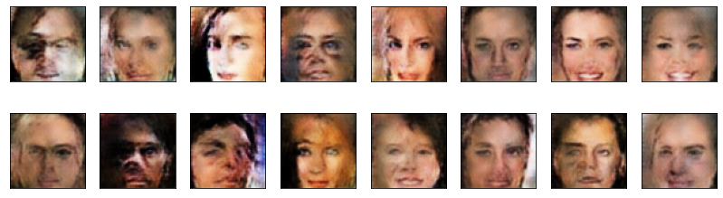

```
2024-09-11 07:24:02 | Epoch [5/5] | Batch 0/509 | d_loss: 2.4184 | g_loss: 4.0693
2024-09-11 07:24:08 | Epoch [5/5] | Batch 50/509 | d_loss: 0.3676 | g_loss: 3.0942
2024-09-11 07:24:14 | Epoch [5/5] | Batch 100/509 | d_loss: 0.3732 | g_loss: 5.2312
2024-09-11 07:24:20 | Epoch [5/5] | Batch 150/509 | d_loss: 0.2554 | g_loss: 2.0893
2024-09-11 07:24:26 | Epoch [5/5] | Batch 200/509 | d_loss: 0.4622 | g_loss: 2.9790
2024-09-11 07:24:32 | Epoch [5/5] | Batch 250/509 | d_loss: 0.3464 | g_loss: 3.4479
2024-09-11 07:24:38 | Epoch [5/5] | Batch 300/509 | d_loss: 0.1025 | g_loss: 5.0069
2024-09-11 07:24:44 | Epoch [5/5] | Batch 350/509 | d_loss: 0.3489 | g_loss: 4.0216
2024-09-11 07:24:50 | Epoch [5/5] | Batch 400/509 | d_loss: 0.3357 | g_loss: 2.2460
2024-09-11 07:24:56 | Epoch [5/5] | Batch 450/509 | d_loss: 2.4569 | g_loss: 12.3176
2024-09-11 07:25:02 | Epoch [5/5] | Batch 500/509 | d_loss: 0.2594 | g_loss: 3.4624
```

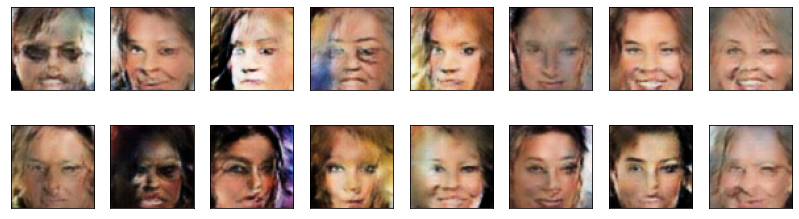

```python
fixed_latent_vector = torch.randn(16, latent_dim, 1, 1).float().cuda()

losses = []
for epoch in range(n_epochs):
    for batch_i, real_images in enumerate(dataloader):
        real_images = real_images.to(device)

        # Train Discriminator
        d_loss = discriminator_step(batch_size, latent_dim, real_images)

        # Train Generator
        g_loss = generator_step(batch_size, latent_dim)

        if batch_i % print_every == 0:
            # Extract the loss value from the dictionary
            d = d_loss['loss']  # Access the loss value from the dictionary
            g = g_loss['loss']  # Access the loss value from the dictionary
            losses.append((d, g))

            # Print discriminator and generator loss
            time = str(datetime.now()).split('.')[0]
            print(f'{time} | Epoch [{epoch+1}/{n_epochs}] | Batch {batch_i}/{len(dataloader)} | d_loss: {d:.4f} | g_loss: {g:.4f}')

    # Display images during training
    generator.eval()
    generated_images = generator(fixed_latent_vector)
    display(generated_images)
    generator.train()
```

### Training losses

Plot the training losses for the generator and discriminator.

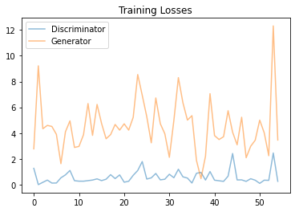

```python
"""
DO NOT MODIFY ANYTHING IN THIS CELL
"""
fig, ax = plt.subplots()
losses = np.array(losses)
plt.plot(losses.T[0], label='Discriminator', alpha=0.5)
plt.plot(losses.T[1], label='Generator', alpha=0.5)
plt.title("Training Losses")
plt.legend()
```

### Question: What do you notice about your generated samples and how might you improve this model?

When you answer this question, consider the following factors:

- The dataset is biased; it is made of "celebrity" faces that are mostly white
- Model size; larger models have the opportunity to learn more features in a data feature space
- Optimization strategy; optimizers and number of epochs affect your final result
- Loss functions

**Answer:**

### Observations on Generated Samples:

1. Bias in Dataset:

The dataset is composed mostly of celebrity faces, which are predominantly white. This bias is reflected in the generated samples, leading to a lack of diversity in the outputs. The model has likely learned to generate faces that mostly resemble those in the training data, resulting in underrepresentation of other ethnic groups, ages, and facial characteristics.

1. Model Size:

If the model is relatively small, it may struggle to capture complex features from the dataset. As a result, generated samples may lack fine details such as facial expressions, textures, or variations in hair and skin tones. A larger model could potentially learn a richer set of features, leading to more realistic and varied generated faces.

1. Optimization Strategy:

The choice of optimizer and number of epochs play a crucial role in the final quality of generated samples. If the model is not trained for enough epochs, it may underfit and produce blurry or unrealistic images. On the other hand, too many epochs can lead to overfitting, where the model memorizes the training data and generates overly similar or less diverse images. Additionally, using a better optimizer (e.g., Adam with carefully tuned learning rates) can lead to faster and more stable convergence.

1. Loss Functions:

The loss functions used for training both the generator and discriminator have a direct impact on the quality of generated samples. For example, if the adversarial loss is poorly balanced between the generator and discriminator, the generator might produce images that fool the discriminator but don't necessarily look realistic to a human observer. Incorporating perceptual loss or using more advanced loss functions like Wasserstein loss could help the model generate more realistic outputs.

### Potential Improvements:

1. Data Augmentation:

To address the bias in the dataset, consider augmenting the training data with more diverse faces that represent different races, ages, and genders. This could help the model learn a broader range of facial features, leading to more varied and inclusive outputs.

1. Model Size:

Increasing the model size (e.g., using a deeper network with more parameters) could help capture more complex features and improve the quality of the generated faces. However, this comes at the cost of increased training time and computational resources.

1. Optimization and Regularization:

Fine-tune the learning rate and experiment with different optimizers (e.g., AdamW or RMSprop) to achieve more stable and efficient training. Additionally, using techniques like gradient penalty (in Wasserstein GANs) or label smoothing can help regularize the model and improve overall performance.

1. Improving Loss Functions:

Introduce more sophisticated loss functions like Wasserstein loss or hinge loss to balance the training of the generator and discriminator. You could also experiment with perceptual loss, which compares high-level features from a pre-trained network like VGG, to help the generator produce images that look more realistic and sharp.

### Submitting This Project

When submitting this project, make sure to run all the cells before saving the notebook. Save the notebook file as "dlnd_face_generation.ipynb".

Submit the notebook using the *SUBMIT* button in the bottom right corner of the Project Workspace.